# AD2 - Problema 2

Lilia Sampaio

November 4, 2014

**- Ao longo dos anos, houve crescimento no lançamento de músicas?**

Para responder a essa pergunta, optei pelo uso de um gráfico de linhas simples, onde o eixo x corresponde aos anos ao longo do tempo, e o eixo y à quantidade de músicas lançadas. Os pontos representam os anos incluídos na base de dados (base considerada foi o txt de músicas por ano presente no documento do problema). Podemos ver o resultado no gráfico a seguir:

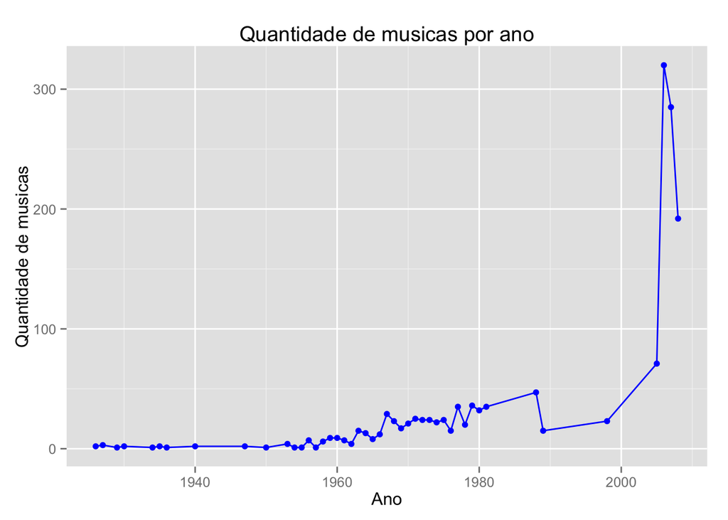

Analisando a figura acima, podemos dizer que ao longo do tempo o comportamento do lançamento de músicas foi relativamente constante nos primeiros anos, com um pequeno crescimento no período de 1960 à 1980, uma queda após esse período próximo ao ano 2000 e depois picos isolados após esse mesmo ano.

De modo geral, concluo que houve crescimento mais acelerado do ano 2000 pra cá. Isso significa, por exemplo, que o interesse das pessoas pela indústria musical, artistas e álbuns cresceu ao longo do tempo, e por isso, produtos relacionados a esse meio foram sendo lançados em maior quantidade.

**- Qual a variação de estilos musicais ao longo do tempo?**

Nessa pergunta, fiz uso de um gráfico de área, onde o eixo x correspondia aos anos ao longo do tempo, o eixo y à quantidade de músicas por tag e as cores representando as tags escolhidas para esse estudo, baseeadas na recorrência das mesmas na base de dados. Podemos ver o resultado no gráfico a seguir:

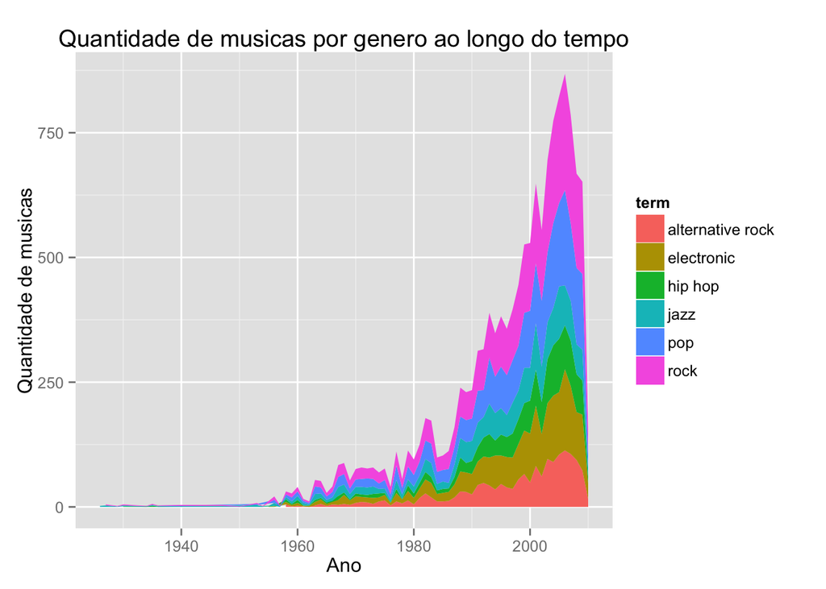

Analisando a figura acima, podemos ver que o estilo musical que lançou mais músicas ao longo do tempo foi o *rock*. Também podemos dizer que todos os estilos apresentaram, no geral, crescimento do início das observações até o final, após o ano 2000. Entre 1940 e 1960 podemos dizer que os estilos estavam todos num mesmo patamar lançando uma mesma quantidade de músicas. A partir dai já podemos ver uma tendência dos estilos *rock* e *pop* se firmando como mais lançadas.